# Practical Machine Learning Course Project

##### Author: Kelly Yap Suet Chyi

### Overview

In this project, there are 2 sets of data given. These are the data from accelerometers on the belt, forearm, arm and dumbell of 6 participants. Participants were asked to perform barbell lifts correctly and incorrectly in 5 different ways. The training dataset consists of accelerometer data and a label identifying the quality of the activity the participant was doing. The testing dataset consists of accelerometer data without the identifying label. The goal of this project is to predict the labels in the test set obversation based on the model built using the training set.

### Data Processing

Load the basic packages, and read in the training and testing data.

```r
#Basic Settings
library(caret)
library(ggplot2)
library(lattice)
library(randomForest)
library(rpart)
library(rpart.plot)
library(rattle)

#Read training and testing datasets
Train <- read.csv("pml-training.csv", na.strings = c("NA", ""))
Test <- read.csv("pml-testing.csv", na.strings = c("NA", ""))
```

First glance at the training set.

```r
#Get the total number of records and variables
dim(Train)
```

```
## [1] 19622   160
```

```r
#Group the variable - classe and get the total count of each group
summary(Train$classe)
```

```
##    A    B    C    D    E
## 5580 3797 3422 3216 3607
```

There are 19,622 records with 160 variables, and with five different classes(A,B,C,D,E) in the training set.Variable - classe is the variable that we need to predict in the testing set.  
From the training set, splitting the dataset into 2 (70% and 30%) in order to estimate the out of sample error. The larger set (SubTrain) is used to train the model, the smaller set (SubTest) is used to test the performance of the model.

```r
set.seed(100)
inTrain <- createDataPartition(y=Train$classe, p=0.7, list=F)
SubTrain <- Train[inTrain, ]
SubTest <- Train[-inTrain, ]
dim(SubTrain)
```

```
## [1] 13737   160
```

```r
dim(SubTest)
```

```
## [1] 5885  160
```

Some of the variables are mostly NA. Thus, removing those variables since they are not useful in building the model.

```r
# remove variables that are mostly NA
NAVar <- sapply(SubTrain, function(x) mean(is.na(x))) > 0.95
SubTrain <- SubTrain[, NAVar==F]
SubTest <- SubTest[, NAVar==F]
dim(SubTrain)
```

```
## [1] 13737    60
```

```r
dim(SubTest)
```

```
## [1] 5885   60
```

Now SubTrain and SubTest datasets are down to 60 variables.  
Second step is to remove variables with nearly zero variance.

```r
# remove variables with nearly zero variance
ZeroVar <- nearZeroVar(SubTrain)
SubTrain <- SubTrain[, -ZeroVar]
SubTest <- SubTest[, -ZeroVar]
dim(SubTrain)
```

```
## [1] 13737    59
```

```r
dim(SubTest)
```

```
## [1] 5885   59
```

After removing the nearly zero variance variable, There are 59 variables remaining in our datasets.  
The first 7 variables may not be pertinent to the predicting model. Therefore, those can be removed.

```r
# remove the first seven variables that are not pertinent to the prediction model
SubTrain <- SubTrain[, -(1:7)]
SubTest <- SubTest[, -(1:7)]
dim(SubTrain)
```

```
## [1] 13737    52
```

```r
dim(SubTest)
```

```
## [1] 5885   52
```

Now there are 52 variables remaining for building the model.

### Model Building

#### Model #1: Random Forest

For preliminary analysis, random forest algorithm is chosen to build the predicting model on SubTrain dataset. Using 3-fold cross validation to select optimal tuning parameters for the model.

```r
# use 3-fold Cross validation to select optimal tuning parameters
fitControl <- trainControl(method="cv", number=3, verboseIter=F)

# fit random forest model on SubTrain
RFModel <- train(classe ~ ., data=SubTrain, method="rf", trControl=fitControl)
```

After building the model in SubTrain, use the model to predict the classe in SubTest to validate the accuracy.

```r
# validate the random forest model on SubTest
predictedRF <- predict(RFModel, newdata=SubTest)

# show the confusion matrix for random forest Model
confusionMatrix(SubTest$classe, predictedRF)
```

```
## Confusion Matrix and Statistics
##
##           Reference
## Prediction    A    B    C    D    E
##          A 1673    1    0    0    0
##          B    9 1127    3    0    0
##          C    0    4 1018    4    0
##          D    0    0   13  951    0
##          E    0    0    3    1 1078
##
## Overall Statistics
##
##                Accuracy : 0.9935
##                  95% CI : (0.9911, 0.9954)
##     No Information Rate : 0.2858
##     P-Value [Acc > NIR] : < 2.2e-16
##
##                   Kappa : 0.9918
##  Mcnemar's Test P-Value : NA
##
## Statistics by Class:
##
##                      Class: A Class: B Class: C Class: D Class: E
## Sensitivity            0.9946   0.9956   0.9817   0.9948   1.0000
## Specificity            0.9998   0.9975   0.9983   0.9974   0.9992
## Pos Pred Value         0.9994   0.9895   0.9922   0.9865   0.9963
## Neg Pred Value         0.9979   0.9989   0.9961   0.9990   1.0000
## Prevalence             0.2858   0.1924   0.1762   0.1624   0.1832
## Detection Rate         0.2843   0.1915   0.1730   0.1616   0.1832
## Detection Prevalence   0.2845   0.1935   0.1743   0.1638   0.1839
## Balanced Accuracy      0.9972   0.9965   0.9900   0.9961   0.9996
```

#### Model #2: Decision Tree

Now, trying to build the predicting model by using deicison tree algorithm on the SubTrain dataset.

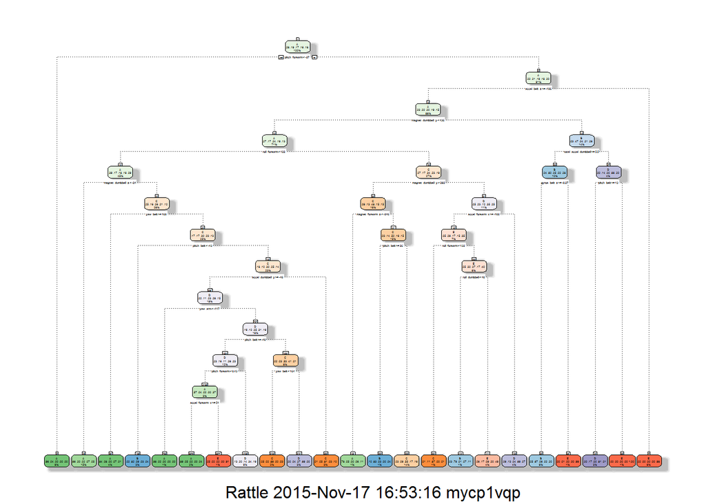

```r
# fit random forest model on SubTrain
DTModel <- rpart(classe ~., data=SubTrain, method="class")

# show the decision tree plot
fancyRpartPlot(DTModel)
```

```r
# validate the decision tree model on SubTest
predictedDT <- predict(DTModel, newdata=SubTest, type="class")

# show the confusion matrix for decision tree
confusionMatrix(SubTest$classe, predictedDT)
```

```
## Confusion Matrix and Statistics
##
##           Reference
## Prediction    A    B    C    D    E
##          A 1502   49   26   77   20
##          B  270  570   77  167   55
##          C   34   58  777  130   27
##          D   98   17  138  648   63
##          E   57  116  169  131  609
##
## Overall Statistics
##
##                Accuracy : 0.6977
##                  95% CI : (0.6858, 0.7094)
##     No Information Rate : 0.3332
##     P-Value [Acc > NIR] : < 2.2e-16
##
##                   Kappa : 0.616
##  Mcnemar's Test P-Value : < 2.2e-16
##
## Statistics by Class:
##
##                      Class: A Class: B Class: C Class: D Class: E
## Sensitivity            0.7659  0.70370   0.6546   0.5620   0.7868
## Specificity            0.9562  0.88788   0.9470   0.9332   0.9075
## Pos Pred Value         0.8973  0.50044   0.7573   0.6722   0.5628
## Neg Pred Value         0.8910  0.94943   0.9156   0.8974   0.9656
## Prevalence             0.3332  0.13764   0.2017   0.1959   0.1315
## Detection Rate         0.2552  0.09686   0.1320   0.1101   0.1035
## Detection Prevalence   0.2845  0.19354   0.1743   0.1638   0.1839
## Balanced Accuracy      0.8611  0.79579   0.8008   0.7476   0.8471
```

The decision tree confusion matrix shows that the accuracy is 69.77% with the out of sample error of 30.23%.  
The above two confusion matrices (Random Forest and Decision Tree) indicate that the accuracy on random forest is way higher than decision tree, thus random forest will be chosen to predict on the test dataset.

### Model Evaluation

Now, use the final selected model fit on training set to predict the classe in the testing set.

```r
# predict on testing set
predictedtest <- predict(RFModel, newdata=Test)
```

### Submission to Coursera

Write those predictions to files for submission in Coursera.

```r
# create function to write predictions to files
pmltofile <- function(x){
  n <- length(x)
  for(i in 1:n) {
    filename <- paste0("problem_id_", i, ".txt")
    write.table(x[i], file=filename, quote=F, row.names=F, col.names=F)
  }
}

# create prediction files for submission
pmltofile(predictedtest)
```